# Project 3 - Wine Analysis

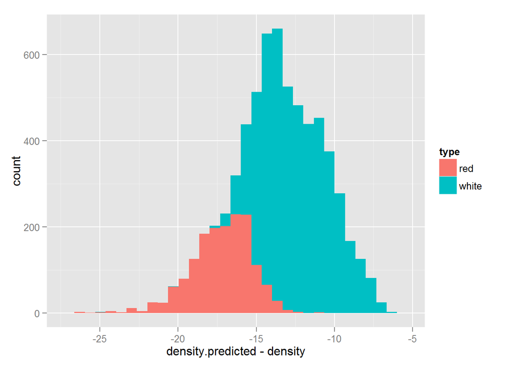

```r
ggplot(wine,aes(density.predicted-density,fill=type))+geom_histogram()
```

Not close for making up the discrepancy because of the low amount in the wine. It is correlated with acidity, and citric acid has a density of 1660 g/L. Tartaric acid also had a density of 1790 g/L.I’m going to include all the relevant densities in this final plot. Lets try these!

```r
wine$density.predicted = 789*wine$alcohol
wine$density.predicted = wine$density.predicted + 1587*wine$residual.sugar/10
wine$density.predicted = wine$density.predicted + 1032*wine$total.sulfur.dioxide/10
wine$density.predicted = wine$density.predicted + 1660*wine$citric.acid/10+1790*wine$fixed.acidity/10+1050*wine$volatile.acidity/10
wine$density.predicted = wine$density.predicted + (100-wine$alcohol-wine$residual.sugar/10-wine$total.sulfur.dioxide/10-wine$citric.acid/10-wine$fixed.acidity/10-wine$volatile.acidity/10)*1000
wine$density.predicted = wine$density.predicted/100
summary(wine$density.predicted)
```

```
##    Min. 1st Qu.  Median    Mean 3rd Qu.    Max.
##   975.3   983.8   986.6   987.0   989.6  1021.0
```

```r
summary(wine$density)
```

```
##    Min. 1st Qu.  Median    Mean 3rd Qu.    Max.
##   987.1   992.3   994.9   994.7   997.0  1039.0
```

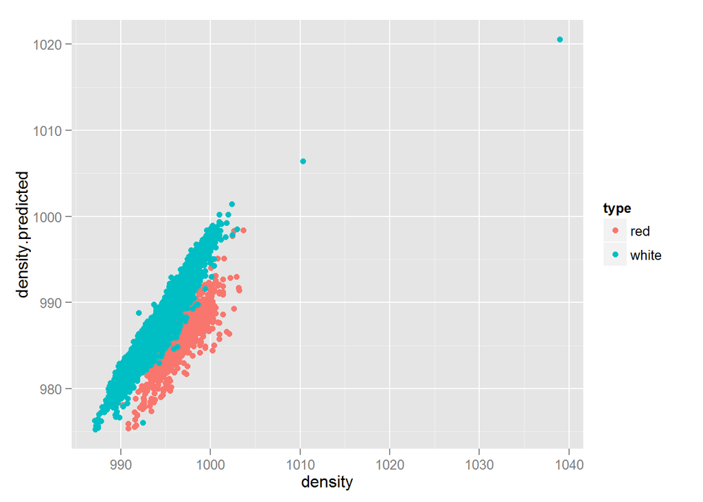

```r
ggplot(wine,aes(x=density,y=density.predicted,color=type))+geom_point()
```

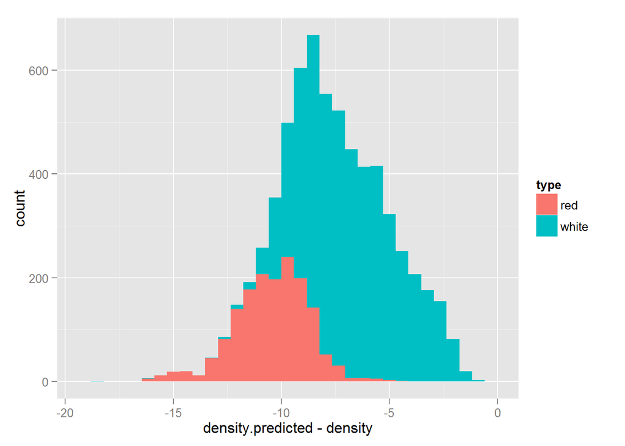

```r
ggplot(wine,aes(density.predicted-density,fill=type))+geom_histogram()
```

```r
summary(wine$sulphates)
```

```
##    Min. 1st Qu.  Median    Mean 3rd Qu.    Max.
##  0.2200  0.4300  0.5100  0.5313  0.6000  2.0000
```

### New Quality Factors

```r
wine$Quality <- ifelse(as.numeric(wine$quality)+2 < 7,"Avg Rating <= 6","Avg Rating >= 7")
wine$Quality <- factor(wine$Quality)
summary(factor(wine$Quality))
```

```
## Avg Rating <= 6 Avg Rating >= 7
##            5220            1277
```

Remake some of the previous plots with new quality classification

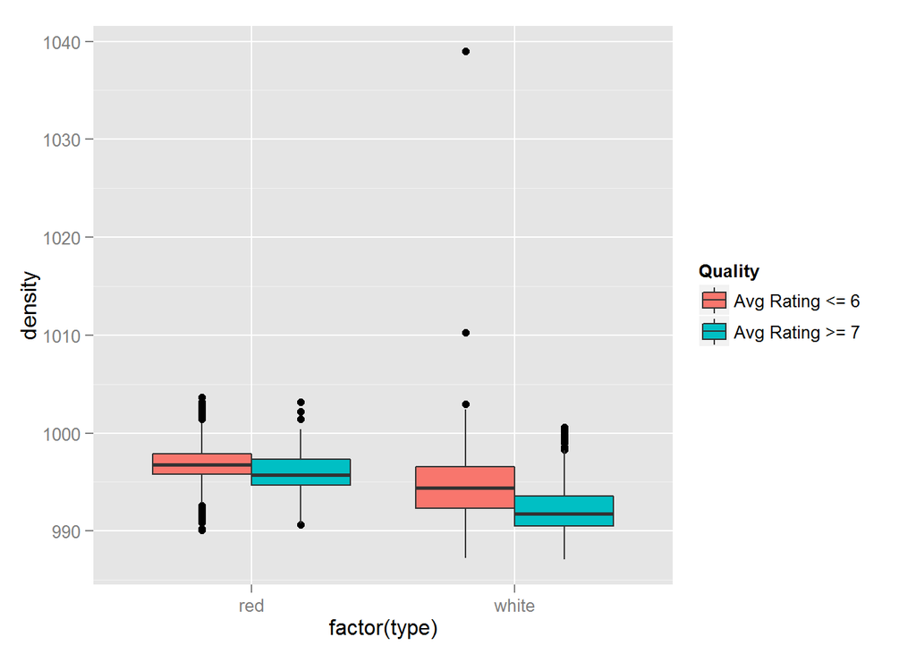

```r
ggplot(wine,aes(factor(type),density,fill=Quality))+geom_boxplot()
```

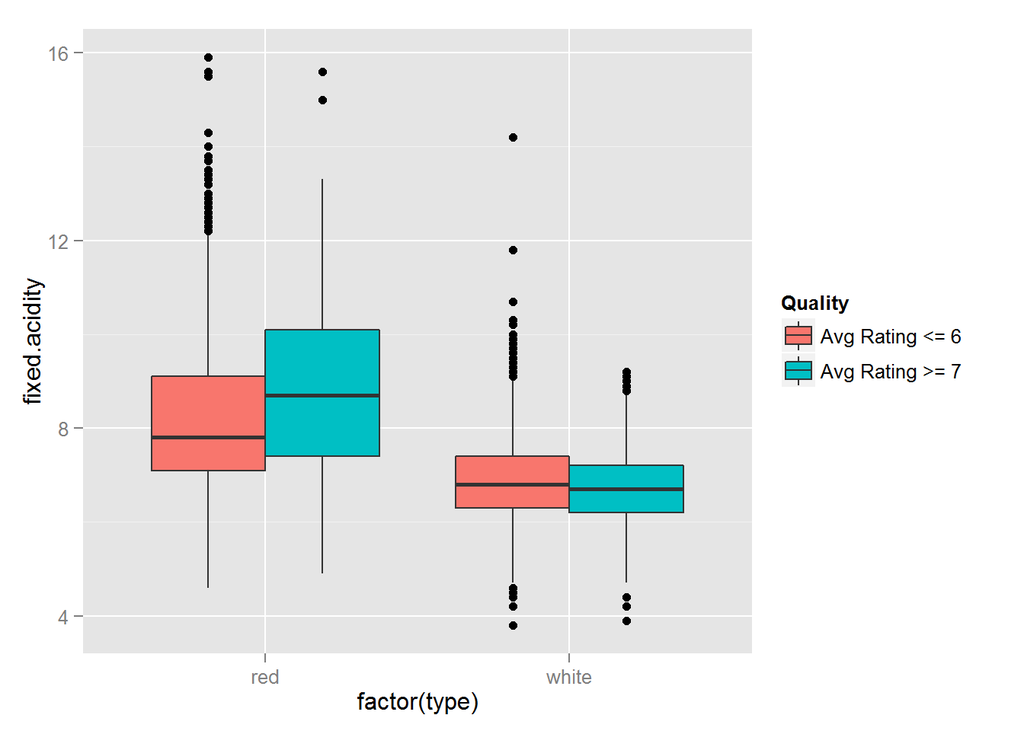

```r
ggplot(wine,aes(factor(type),fixed.acidity,fill=Quality))+geom_boxplot()
```

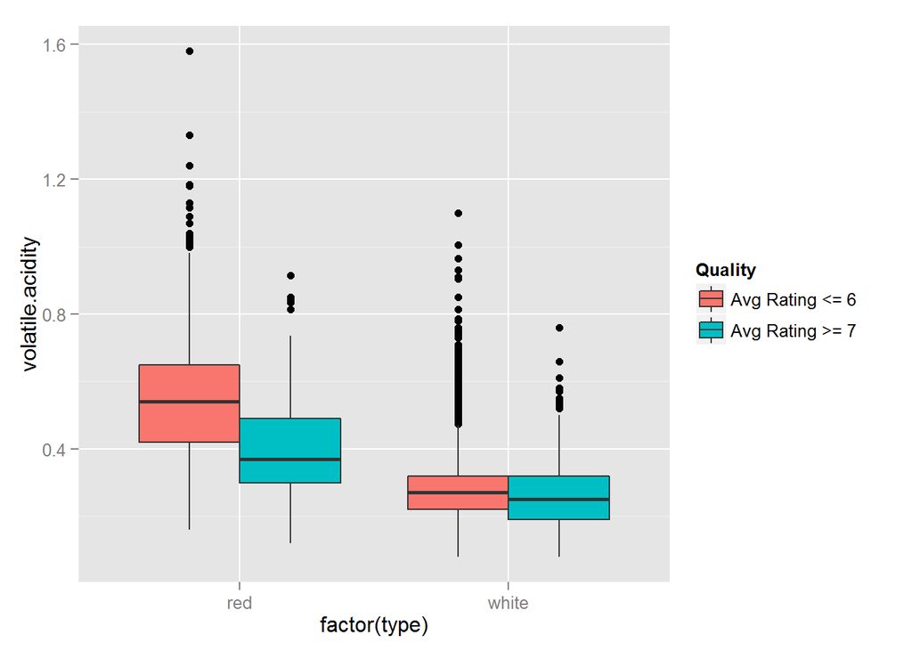

```r
ggplot(wine,aes(factor(type),volatile.acidity,fill=Quality))+geom_boxplot()
```

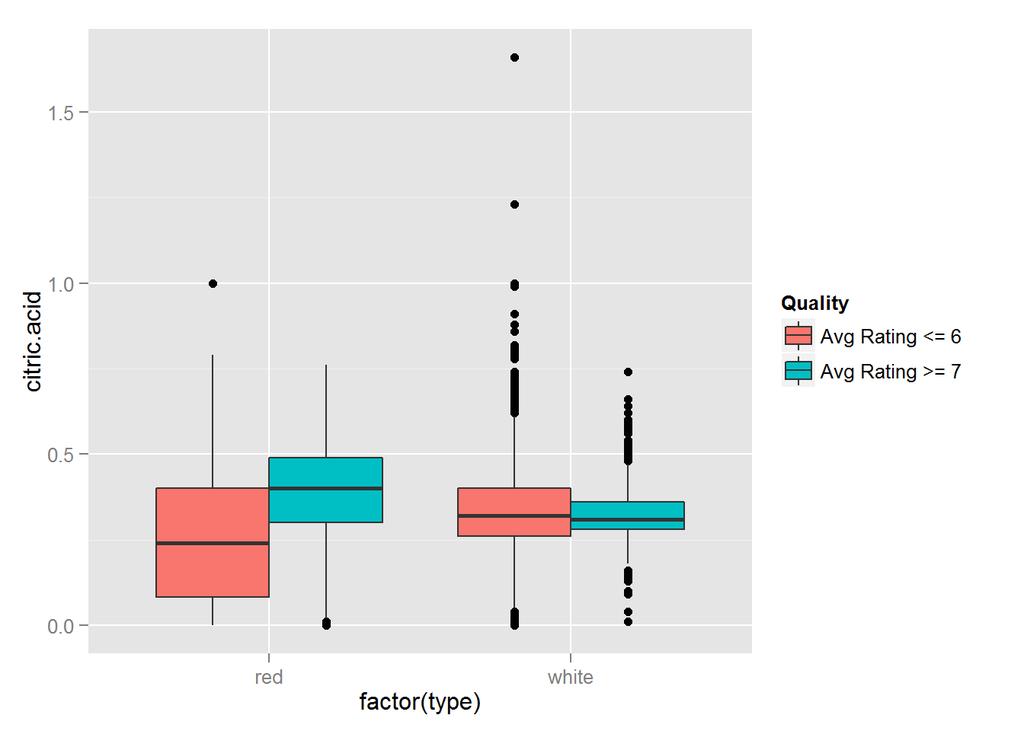

```r
ggplot(wine,aes(factor(type),citric.acid,fill=Quality))+geom_boxplot()
```

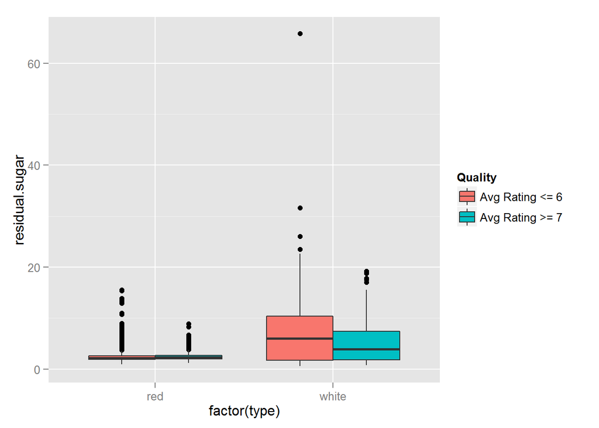

```r
ggplot(wine,aes(factor(type),residual.sugar,fill=Quality))+geom_boxplot()
```

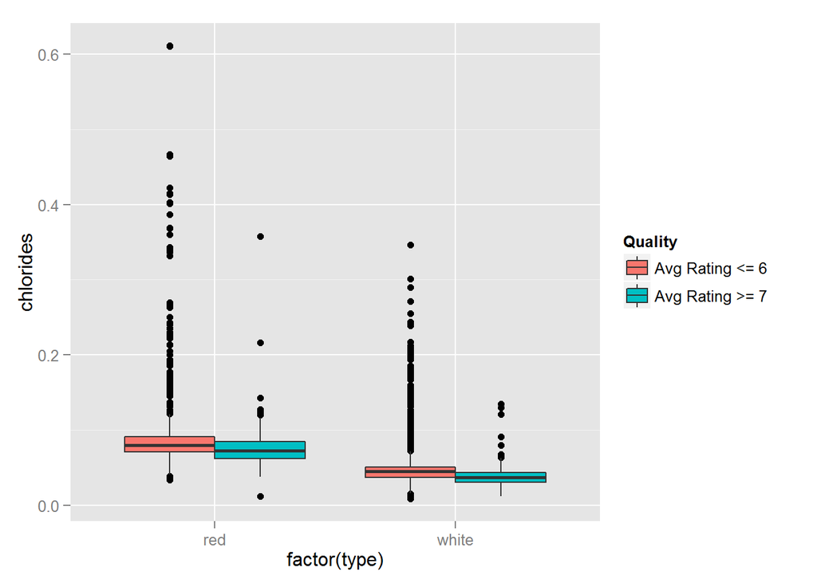

```r
ggplot(wine,aes(factor(type),chlorides,fill=Quality))+geom_boxplot()
```

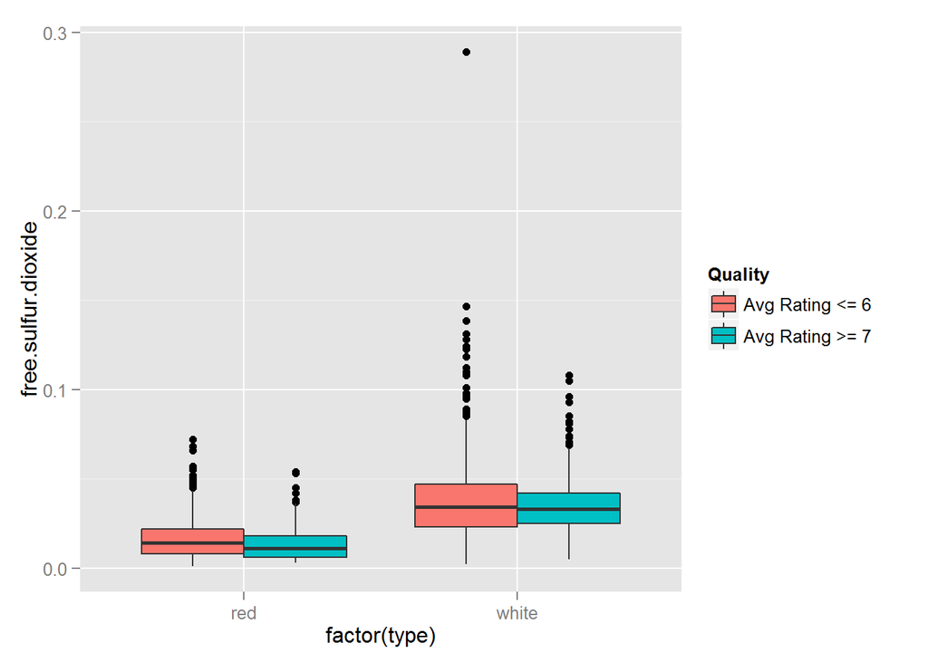

```r
ggplot(wine,aes(factor(type),free.sulfur.dioxide,fill=Quality))+geom_boxplot()
```

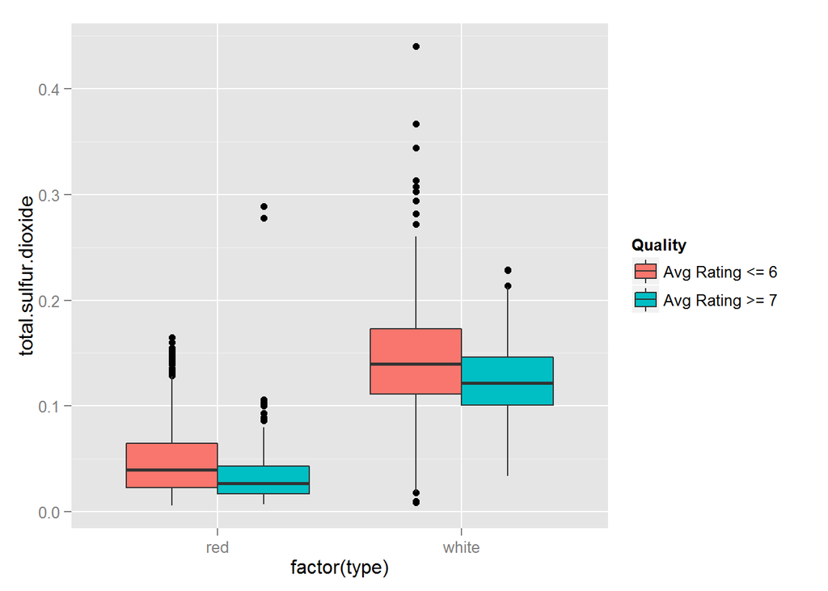

```r
ggplot(wine,aes(factor(type),total.sulfur.dioxide,fill=Quality))+geom_boxplot()
```

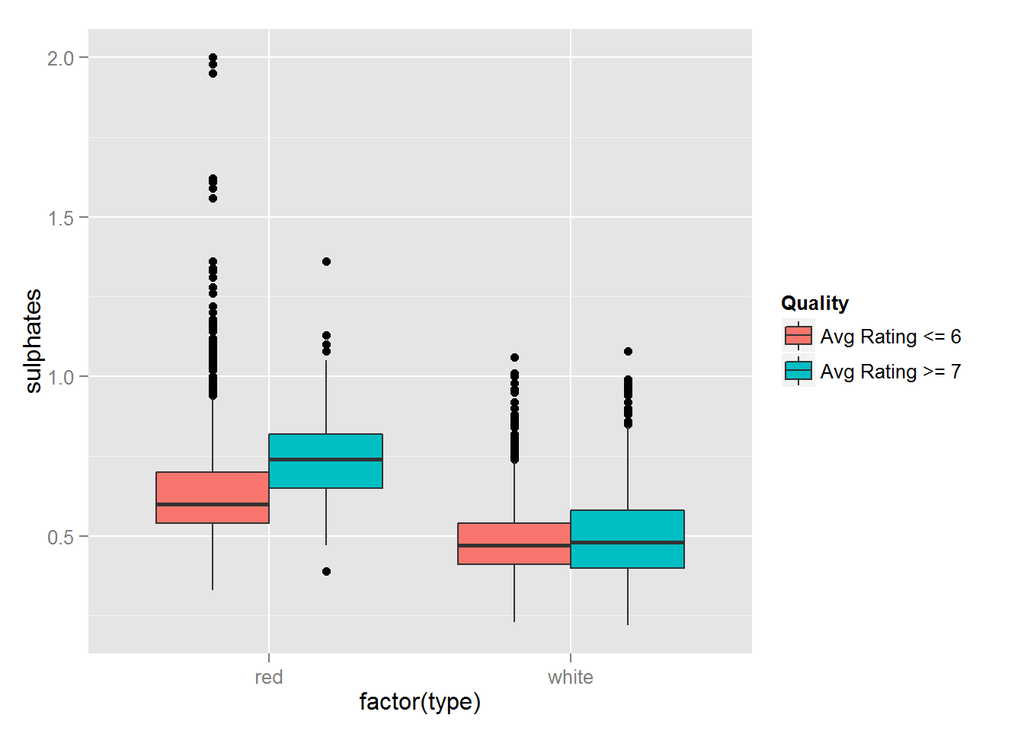

```r
ggplot(wine,aes(factor(type),sulphates,fill=Quality))+geom_boxplot()
```

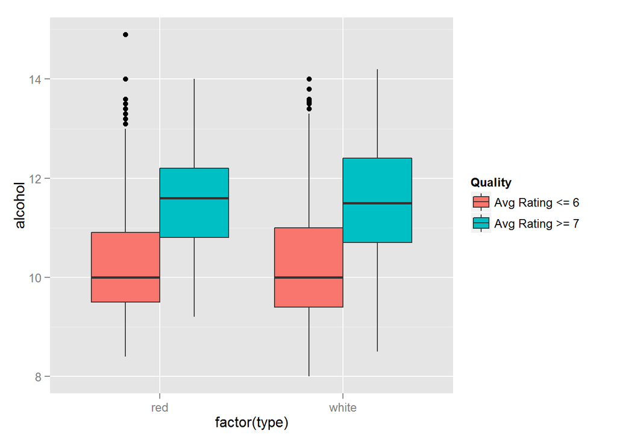

```r
ggplot(wine,aes(factor(type),alcohol,fill=Quality))+geom_boxplot()
```

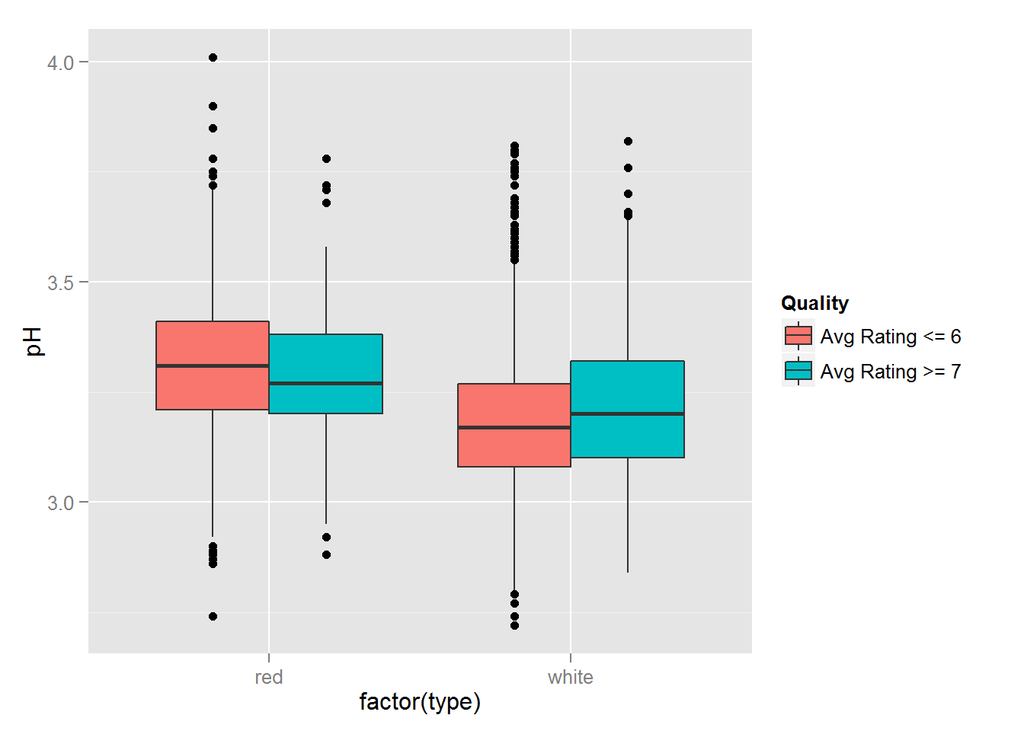

```r
ggplot(wine,aes(factor(type),pH,fill=Quality))+geom_boxplot()
```

# Final Plots and Summary

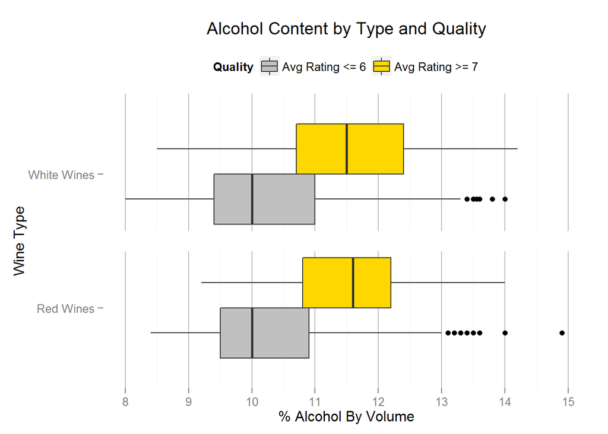

```r
ggplot(wine,aes(type,alcohol,fill=Quality))+
  xlab("Wine Type")+
  ylab("% Alcohol By Volume")+
  ggtitle("Alcohol Content by Type and Quality")+
  coord_flip()+
  theme(panel.grid.major.y = element_blank(),
        panel.grid.minor.y = element_blank(),
        panel.background = element_blank(),
        legend.position="top",
        panel.grid.major.x = element_line(color='gray'))+
  scale_y_continuous(limits=c(8,15),breaks=c(8,9,10,11,12,13,14,15))+
  scale_x_discrete(limits=c("red","white"),labels=c("Red Wines","White Wines"))+
  scale_fill_manual(name = "Quality", values = c("#C0C0C0", "gold"))+
  geom_vline(xintercept=1.5,size=8, color='white')+
  geom_boxplot()
```

The above box plot shows the alcohol content of white wines (top) and red wines (bottom) for high qualities wines (gold) and lower qualities wines (silver). Across wine types, higher alcohol content is associated with being a wine that is rated higher.

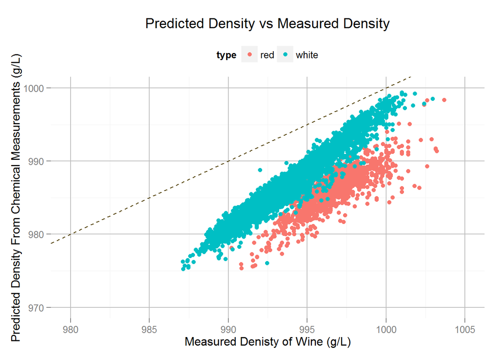

```r
ggplot(wine,aes(x=density,y=density.predicted,color=type))+
  theme(panel.background = element_blank(),
        legend.position="top",
        panel.grid.major = element_line(color='gray'))+
  xlab("Measured Denisty of Wine (g/L)")+
  ylab("Predicted Density From Chemical Measurements (g/L)")+
  ggtitle("Predicted Density vs Measured Density")+
  scale_y_continuous(limits=c(970,1000))+
  scale_x_continuous(limits=c(980,1005))+
  geom_abline(intercept=0,slope=1,linetype=2,color='#554400',)+
  geom_point()
```

The above plot shows the predicted density for the wine based on all the chemical measurements vs the measured density of the wine. The dashed line shows the values at which the two values would back. Since the points all fall below the line, the measured density is systematically higher than the predicted density. Additionally, there is something about red and white wines that make this discrepancy systematically different.

[figure not shown]

```r
ggplot(red,aes(x=quality,y=volatile.acidity,))+
  theme(panel.background = element_blank(),
        legend.position="top",
        panel.grid.major = element_line(color='gray'))+
  xlab("Average Wine Rating")+
  ylab("Tartaric Acid Density (g/L)")+
  ggtitle("Fixed Acidity vs Average Rating for Red Wines")+
  geom_line(stat='summary',fun.y=mean,color="#990000",size=1.2)+
  geom_line(stat='summary',fun.y=quantile,prob=0.25,linetype=2,color="#990000",size=1)+
  geom_line(stat='summary',fun.y=quantile,prob=0.75,linetype=2,color="#990000",size=1)+
  geom_line(stat='summary',fun.y=quantile,prob=0.1,linetype=3,color="#990000")+
  geom_line(stat='summary',fun.y=quantile,prob=0.9,linetype=3,color="#990000")
```

# Reflection

This analysis was interesting and challenging for a number of reasons. One, these are chemical properties and I know I did not use the proper concentration models for chemical properties. Also, this is a data set that is not well documented on how it was assembled, how the quantities were measured, or the errors associated with the measurements. I personally would have also liked to know the temperature of the wines and the altitude of measurements. A number of chemical properties and their affect on taste depend on these values.